# PD5

Dominik Rafacz

29 - 04 - 2019

# 1 Wstęp

W niniejszej pracy domowej będziemy badać drzewa decyzyjne z pakietu *rpart* na zbiorze danych *Titanic* (pochodzącym z [kaggle](https://www.kaggle.com/c/titanic/data)), podzielonych w sposób losowy na zbiór treningowy (70%) i testowy (30%). Będziemy się również odwoływać do [artykułu](https://arxiv.org/pdf/1802.09596.pdf) proponującego domyślne hiperparametry do różnych modeli, w tym do *rpart*.

```r
dset <- read.csv("train.csv")
dset <- dset[,-c(1,4,9, 11)]

len <- nrow(dset)

set.seed(42)
trainind <- sample(len, ceiling(len*7/10))
testind <- setdiff(1:len, trainind)

lentr <- length(trainind)
lents <- length(testind)

validind <- sample(testind, ceiling(lents*0.5))
newtest <- setdiff(testind, validind)
```

# 2 Hiperparametry *rpart*

Najpierw opiszemy hiperparametry, jakimi będziemy się zajmować:

- **cp** - parametr złożoności (ang. complexity parameter, abr. cp) – jest to czynnik, o jaki dany podział węzła powininen minimalnie zmiejszyć niedopasowanie modelu, tzn. jeśli proponowany przez model nowy podział zmniejszy niedopasowanie o mniej niż **cp**, podział jest odrzucany.
  - Wartość domyślna: *0.01*.
  - Wartość proponowana: *0* (czyli potencjalny podział jest dokonywany zawsze, nawet jeśli zmniejsza niedopasowanie o minimalną niezerową wartość).
- **maxdepth** - maksymalna głębokość węzła – określa, jak długa może być ścieżka od liścia do korzenia. Jeśli któryś z węzłów znajduje się już na takiej głębokości, nie są dokonywane dalsze jego podziały.
  - Wartość domyślna: *30*.
  - Wartość proponowana: *21*.
- **minbucket** - minimalny rozmiar liścia – określa, ile minimalnie może się znajdować obserwacji w liściu. Jeśli podział sprawiłby, że w nowych liściach obserwacji byłoby mniej, nie będzie on dokonywany.
  - Wartość domyślna: *7*.
  - Wartość proponowana: *12*.
- **minsplit** - minimalna liczba podziału – określa, ile minimalnie może się znajdować obserwacji w węźle, aby móc dokonać podziału. Jeśli liczba elementów w węźle jest mniejsza, nie będzie dokonywanych więcej podziałów. Oczywiście **minsplit** >= 2* **minbucket**.
  - Wartość domyślna: *20*.
  - Wartość proponowana: *24*.

Jeszcze jednym parametrem, który w artykule nie jest strojony, a którym będziemy zajmować się później, jest reguła podziału, **split**, która określa według jakiego kryterium będziemy się kierowali, rozpatrując różne podziały dla danego node’a i wybierając najlepsze z nich. *information* określa jak zmieni się informacja zawarta w obserwacji, a *gini* – jak zmieni się indeks Giniego.

# 3 Drzewo dla parametrów proponowanych

Na wyodrębnionym zbiorze treningowym, zasadzimy teraz drzewo, wykorzystując proponowane w artykule parametry. Sprawdzimy na zbiorze testowym, jaka jest jego *accuracy* (acc) i *area under ROC curve* (auc).

```r
pars_p <- list(cp = 0,
               maxdepth = 21,
               minbucket = 12,
               minsplit = 24)

tsk <- makeClassifTask("task", data = dset, target = "Survived")
lrn_p <- makeLearner("classif.rpart", par.vals = pars_p, predict.type  = "prob")

tree_p <- train(lrn_p, tsk, subset = trainind)
res_p <- predict(tree_p, tsk, subset = testind)

performance(res_p, measures = list(acc, auc))
```

```
##       acc       auc
## 0.8014981 0.8629126
```

# 4 Drzewo dla parametrów domyślnych

Powtórzymy teraz proces dla parametrów domyślnych z paczki.

```r
pars_d <- list(cp = 0.01,
               maxdepth = 30,
               minbucket = 7,
               minsplit = 20)

lrn_d <- makeLearner("classif.rpart", par.vals = pars_d, predict.type = "prob")

tree_d <- train(lrn_d, tsk, subset = trainind)
res_d <- predict(tree_d, tsk, subset = testind)

performance(res_d, measures = list(acc, auc))
```

```
##       acc       auc
## 0.8014981 0.8166184
```

Jak widzimy, choć acc obu modeli jest identyczne, auc na parametrach proponowanych jest nieco lepsze.

# 5 Drzewo dla parametrów random search

Spróbujemy jeszcze dostroić hiperparametry metodą ich losowania z dostępnej siatki. Siatkę przyjmiemy taką samą jak w artykule.

```r
pars_set <- makeParamSet(
  makeNumericParam("cp", 0, 1),
  makeIntegerParam("maxdepth", 1, 30),
  makeIntegerParam("minsplit", 1, 60),
  makeIntegerParam("minbucket", 1, 60)
)

pars_r <- tuneParams(
  makeLearner("classif.rpart", predict.type = "prob"),
  tsk,
  makeFixedHoldoutInstance(trainind, validind, size = len),
  par.set = pars_set,
  control = makeTuneControlRandom(maxit = 500),
  measures = list(auc, acc),
  show.info = FALSE)

lrn_r <- makeLearner("classif.rpart", par.vals = pars_r$x, predict.type = "prob")
tree_r <- train(lrn_r, tsk, subset = trainind)
res_d <- predict(tree_d, tsk, subset = newtest)

performance(res_d, measures = list(acc, auc))
```

```
##       acc       auc
## 0.8270677 0.7986609
```

# 6 Wizualizacja drzewa

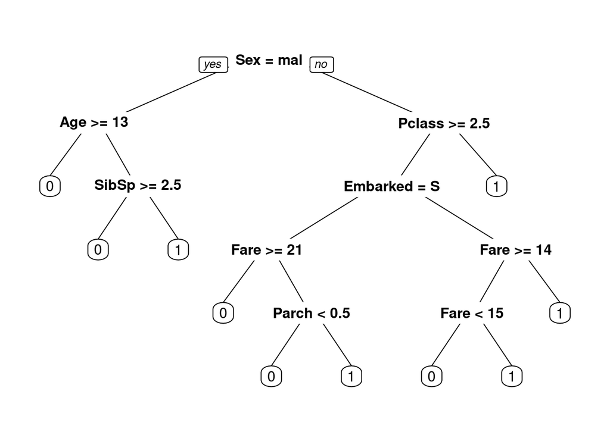

```r
prp(tree_d$learner.model, roundint = FALSE)
```

Każdy z napisów postaci *nazwaCechy =/>=/< wartość* reprezentuje jeden z węzłów nieliściastych drzewa. Napis oznacza warunek logiczny, według którego obserwacje są dzielone. Na lewo znajduje się węzeł z obserwacjami, które warunek spełniają, podczas gdy na prawo – węzeł z obserwacjami warunku niespełniającymi. Na okrągło narysowane są liście wraz z wartością cechy docelowej *Survived*, jaka przydzielana jest wartościom lądującym w określonym liściu.

Za pomocą rysunku możemy łatwo prześledzić schemat decyzyjny i zobaczyć, jakie są najważniejsze zmienne rozdzielające obserwacje rozdzielające zbiór.

# 7 Podział za pomocą indeksu Giniego

Na końcu porównamy jeszcze ze sobą skuteczność drzew zbudowanych z parametrami z artykułu, ale z różną metodą podziału. Dla domyślnej wartości – *gini* – zbudowaliśmy już model. Teraz zbudujemy drzewo z metodą *information gain*.

```r
pars_s <- list(parms = list(split = "information"),
               cp = 0,
               maxdepth = 21,
               minbucket = 12,
               minsplit = 24)

lrn_s <- makeLearner("classif.rpart", par.vals = pars_s, predict.type = "prob")

tree_s <- train(lrn_s, tsk, subset = trainind)
res_s <- predict(tree_s, tsk, subset = testind)

performance(res_s, measures = list(acc, auc))
```

```
##       acc       auc
## 0.8014981 0.8599305
```

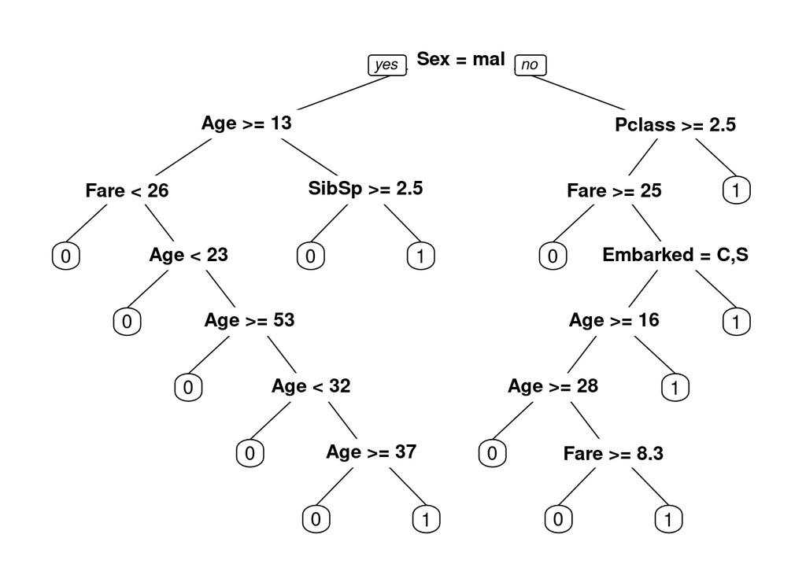

```r
prp(tree_s$learner.model, roundint = FALSE)
```

Możemy zauważyć, że w stosunku do poprzedniego ma ono więcej rozgałęzień, występuje wiele “pojedynczych” gałęzi (tzn. takich, które od razu kończą się liściem).